# BUDA 525 HW 2

Valentina Tippy

2025-09-07

# Q1

[figure not shown]

```r
library(alr4)
data(UBSprices)
##Scatter Plot, Simple Linear Regression
plot(UBSprices$bigmac2003, UBSprices$bigmac2009,
     xlab = "Big Mac Price 2003",
     ylab = "Big Mac Price 2009",
     main = "Big Mac 2009 vs 2003")
```

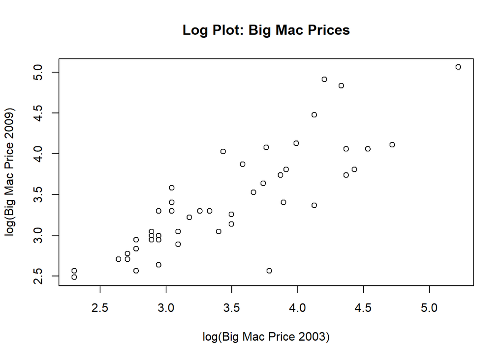

```r
## Scatter Plot, Log Linear Regression
  plot(log(UBSprices$bigmac2003), log(UBSprices$bigmac2009),
     xlab = "log(Big Mac Price 2003)",
     ylab = "log(Big Mac Price 2009)",
     main = "Log Plot: Big Mac Prices")
```

```r
##Fit Linear Model
model <- lm(log(bigmac2009) ~ log(bigmac2003), data = UBSprices)
summary(model)
```

```
##
## Call:
## lm(formula = log(bigmac2009) ~ log(bigmac2003), data = UBSprices)
##
## Residuals:
##      Min       1Q   Median       3Q      Max
## -1.11379 -0.10663 -0.01378  0.08207  0.89628
##
## Coefficients:
##                 Estimate Std. Error t value Pr(>|t|)
## (Intercept)      0.64031    0.22922   2.793  0.00728 **
## log(bigmac2003)  0.80293    0.06709  11.967  < 2e-16 ***
## ---
## Signif. codes:  0 '***' 0.001 '**' 0.01 '*' 0.05 '.' 0.1 ' ' 1
##
## Residual standard error: 0.3324 on 52 degrees of freedom
## Multiple R-squared:  0.7336, Adjusted R-squared:  0.7285
## F-statistic: 143.2 on 1 and 52 DF,  p-value: < 2.2e-16
```

1. Simple Regression (Graph 1) is not an appropriate choice for the first model since most of the data is confined to <50 with a few points over 50 and an outliar on the high end of 150. Graph 2 is better suited since it has a more linear layout.
2. The regression Coefficients for Graph 2 (Log) tells us that the intercept is .64031, we can use this in a reverse log function (exp) to find the price of what a Big Mac would be in 2009. example: exp(.64031)=1.896 ~ 1.9
3. The slope is .80293, which means the price increase was less than predicted. Perfect slope is 1, we got .80 this means what increased by 1% in 2003 increased by .80% in 2009.

# Q2

```r
library(alr4)
data("oldfaith")
names(oldfaith)
```

```
## [1] "Duration" "Interval"
```

```r
model2 <- lm(Interval ~ Duration, data = oldfaith)
summary(model2)
```

```
##
## Call:
## lm(formula = Interval ~ Duration, data = oldfaith)
##
## Residuals:
##      Min       1Q   Median       3Q      Max
## -12.3337  -4.5250   0.0612   3.7683  16.9722
##
## Coefficients:
##              Estimate Std. Error t value Pr(>|t|)
## (Intercept) 33.987808   1.181217   28.77   <2e-16 ***
## Duration     0.176863   0.005352   33.05   <2e-16 ***
## ---
## Signif. codes:  0 '***' 0.001 '**' 0.01 '*' 0.05 '.' 0.1 ' ' 1
##
## Residual standard error: 6.004 on 268 degrees of freedom
## Multiple R-squared:  0.8029, Adjusted R-squared:  0.8022
## F-statistic:  1092 on 1 and 268 DF,  p-value: < 2.2e-16
```

```r
newdata<- data.frame(Duration=250)
predict(model2, newdata, interval = "confidence", level = 0.95)
```

```
##        fit      lwr      upr
## 1 78.20354 77.36915 79.03794
```

```r
predict(model2, newdata, interval = "prediction", level = 0.95)
```

```
##        fit      lwr      upr
## 1 78.20354 66.35401 90.05307
```

With a 95% confidence interval, we can assume that the next eruption will be between ~77 minutes and ~79 minutes

With a prediction interval, we can assume the next eruption will be between ~66 minutes and ~90 minutes

This is after the occurrence of the last erruption that lasted 250 seconds.

# Q3

```r
library(alr4)
data(UN11)
names(UN11)
```

```
## [1] "region"    "group"     "fertility" "ppgdp"     "lifeExpF"  "pctUrban"
```

```r
Model3 <-lm(fertility~log(ppgdp)+pctUrban, data=UN11)
summary(Model3)
```

```
##
## Call:
## lm(formula = fertility ~ log(ppgdp) + pctUrban, data = UN11)
##
## Residuals:
##      Min       1Q   Median       3Q      Max
## -2.15114 -0.64929 -0.06604  0.63253  2.99102
##
## Coefficients:
##               Estimate Std. Error t value Pr(>|t|)
## (Intercept)  7.9932699  0.3993367  20.016   <2e-16 ***
## log(ppgdp)  -0.6151425  0.0641565  -9.588   <2e-16 ***
## pctUrban    -0.0004393  0.0042656  -0.103    0.918
## ---
## Signif. codes:  0 '***' 0.001 '**' 0.01 '*' 0.05 '.' 0.1 ' ' 1
##
## Residual standard error: 0.9328 on 196 degrees of freedom
## Multiple R-squared:   0.52,  Adjusted R-squared:  0.5151
## F-statistic: 106.2 on 2 and 196 DF,  p-value: < 2.2e-16
```

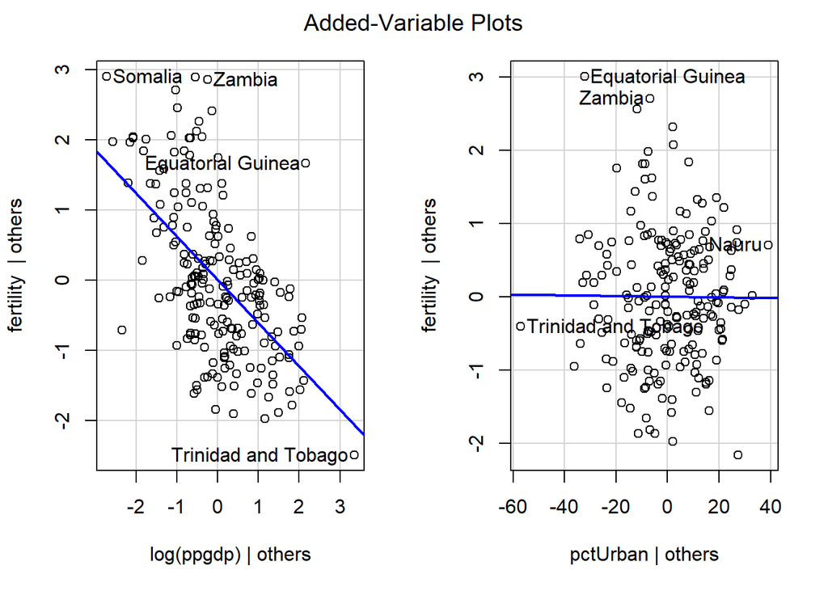

```r
avPlots(Model3)
```

# Q4

Model Q4a (2 PREDICTORS)

```r
library(car)
data("Transact")
names(Transact)
```

```
## [1] "t1"   "t2"   "time"
```

```r
modelq4a <- lm(time ~ t1 + t2, data = Transact)
summary(modelq4a)
```

```
##
## Call:
## lm(formula = time ~ t1 + t2, data = Transact)
##
## Residuals:
##     Min      1Q  Median      3Q     Max
## -4652.4  -601.3     2.4   455.7  5607.4
##
## Coefficients:
##              Estimate Std. Error t value Pr(>|t|)
## (Intercept) 144.36944  170.54410   0.847    0.398
## t1            5.46206    0.43327  12.607   <2e-16 ***
## t2            2.03455    0.09434  21.567   <2e-16 ***
## ---
## Signif. codes:  0 '***' 0.001 '**' 0.01 '*' 0.05 '.' 0.1 ' ' 1
##
## Residual standard error: 1143 on 258 degrees of freedom
## Multiple R-squared:  0.9091, Adjusted R-squared:  0.9083
## F-statistic:  1289 on 2 and 258 DF,  p-value: < 2.2e-16
```

Model Q4b (Average and Difference)

```r
library(car)
data("Transact")
modelq4b <- lm(time~ I((t1+t2)/2)+I(t1-t2), data=Transact)
summary(modelq4b)
```

```
##
## Call:
## lm(formula = time ~ I((t1 + t2)/2) + I(t1 - t2), data = Transact)
##
## Residuals:
##     Min      1Q  Median      3Q     Max
## -4652.4  -601.3     2.4   455.7  5607.4
##
## Coefficients:
##                Estimate Std. Error t value Pr(>|t|)
## (Intercept)    144.3694   170.5441   0.847    0.398
## I((t1 + t2)/2)   7.4966     0.3654  20.514  < 2e-16 ***
## I(t1 - t2)       1.7138     0.2548   6.726 1.12e-10 ***
## ---
## Signif. codes:  0 '***' 0.001 '**' 0.01 '*' 0.05 '.' 0.1 ' ' 1
##
## Residual standard error: 1143 on 258 degrees of freedom
## Multiple R-squared:  0.9091, Adjusted R-squared:  0.9083
## F-statistic:  1289 on 2 and 258 DF,  p-value: < 2.2e-16
```

Model Q4c (T2 and Difference)

```r
library(car)
data("Transact")
modelq4c <- lm(time~ t2 +I(t1-t2), data=Transact)
summary(modelq4c)
```

```
##
## Call:
## lm(formula = time ~ t2 + I(t1 - t2), data = Transact)
##
## Residuals:
##     Min      1Q  Median      3Q     Max
## -4652.4  -601.3     2.4   455.7  5607.4
##
## Coefficients:
##             Estimate Std. Error t value Pr(>|t|)
## (Intercept) 144.3694   170.5441   0.847    0.398
## t2            7.4966     0.3654  20.514   <2e-16 ***
## I(t1 - t2)    5.4621     0.4333  12.607   <2e-16 ***
## ---
## Signif. codes:  0 '***' 0.001 '**' 0.01 '*' 0.05 '.' 0.1 ' ' 1
##
## Residual standard error: 1143 on 258 degrees of freedom
## Multiple R-squared:  0.9091, Adjusted R-squared:  0.9083
## F-statistic:  1289 on 2 and 258 DF,  p-value: < 2.2e-16
```

Model q4d (t1,t2, average, difference)

```r
library(car)
data("Transact")
modelq4d <- lm(time~ t1+t2+I((t1+t2)/2)+I(t1-t2), data=Transact)
summary(modelq4d)
```

```
##
## Call:
## lm(formula = time ~ t1 + t2 + I((t1 + t2)/2) + I(t1 - t2), data = Transact)
##
## Residuals:
##     Min      1Q  Median      3Q     Max
## -4652.4  -601.3     2.4   455.7  5607.4
##
## Coefficients: (2 not defined because of singularities)
##                 Estimate Std. Error t value Pr(>|t|)
## (Intercept)    144.36944  170.54410   0.847    0.398
## t1               5.46206    0.43327  12.607   <2e-16 ***
## t2               2.03455    0.09434  21.567   <2e-16 ***
## I((t1 + t2)/2)        NA         NA      NA       NA
## I(t1 - t2)            NA         NA      NA       NA
## ---
## Signif. codes:  0 '***' 0.001 '**' 0.01 '*' 0.05 '.' 0.1 ' ' 1
##
## Residual standard error: 1143 on 258 degrees of freedom
## Multiple R-squared:  0.9091, Adjusted R-squared:  0.9083
## F-statistic:  1289 on 2 and 258 DF,  p-value: < 2.2e-16
```

There are similarities in the first three model. t1 is equal to difference in model 3. t2 in model 3 is equal to the average in model 2.

Individually the first three models run perfect, however the issue starts when you combine all of them into one summary (Modelq4d). When you run the last model, it gives you NA for Average (I((t1+t2)/2)) and Difference (I(t1-t2)). The reason for this is because those two functions are deemed “redundant” by the program, meaning they give you the same answers as the first two inputs.

Out of the four models I am most likely to chose the first one since it is straight forward with the data. However, the answer could change depending on what our end goal is with the data.